# cm013 Notes and Exercises

# 6 Scatterplot Symbols

You can change the "points" that get plotted in a scatterplot. Anything (?) on your keyboard works with the `shape` argument:

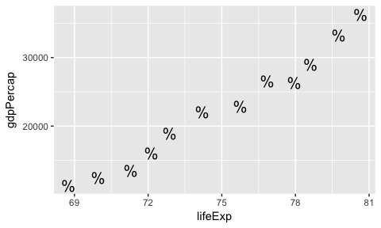

```r
p <- gapminder %>%
    filter(country == "Canada") %>%
    ggplot(aes(lifeExp, gdpPercap))
p + geom_point(shape="%", size=5)
```

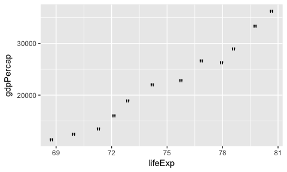

```r
p + geom_point(shape='"', size=5)
```

Or, you can specify a ["`p`lotting `ch`aracter" (pch)](http://www.endmemo.com/program/R/pchsymbols.php) by its symbol number. Let's try `21`.

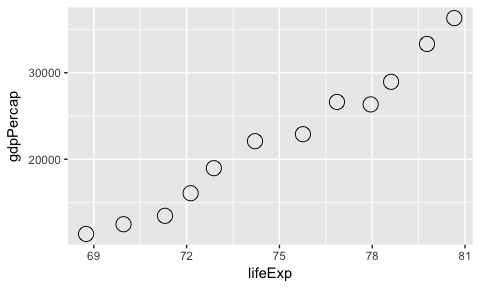

```r
p + geom_point(shape=21, size=5)
```

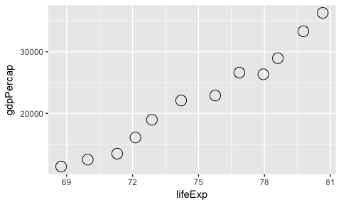

```r
# Also works:
p + geom_point(pch=21, size=5)
```

21-pch is great when used in conjunction with a `size` aesthetic:

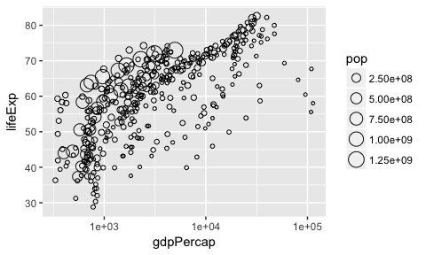

```r
gapminder %>%
    filter(continent=="Asia") %>%
    ggplot(aes(gdpPercap, lifeExp, size=pop)) +
    geom_point(shape=21) +
    scale_x_log10()
```

## Exercise Set 2

1. For the `gapminder` data in 2007, for all continents except Oceania, make a scatterplot of `gdpPercap` vs `lifeExp` facetted by `continent`, so that the size is proportional to the `pop`, the circumference of each circular "point" is black, and the interior is coloured by the country colours in the vector `country_colors` (NOTE: this vector comes with the `gapminder` package). Hide the legend.

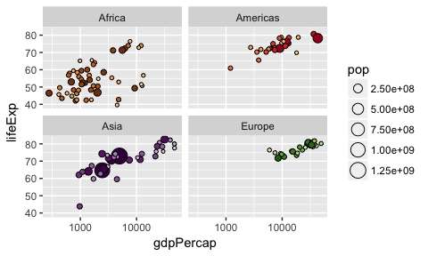

```r
(e2_1 <- gapminder %>%
    filter(year == 2007, continent != "Oceania") %>%
    ggplot(aes(gdpPercap, lifeExp)) +
    facet_wrap(~ continent) +
    geom_point(aes(size=pop,
                   fill=country),
               shape=21) +
    scale_x_log10() +
    scale_fill_manual(values=country_colors,
                      guide=FALSE))
```

1. Save the above plot to file, as a `pdf` and `png`.

```r
# ggsave("tmp/e2_1.png", e2_1)
# ggsave("tmp/e2_1.pdf", e2_1)
```